# Pandas-Bootcamp-Part11

### RegExp and Text Manipulation

- Detailed overview of Python String Methods
- The Pandas .str family of methods
- Advanced Splits and Replacements in Pandas
- Hands-on introduction to RegEx:
  - Character Sets , anchors , metasequences, Quantifiers and more

#### Our Data : Boston Marathon Runners

https://www.udemy.com/course/the-ultimate-pandas-bootcamp-advanced-python-data-analysis/learn/lecture/19363694#overview

This is a Prestigious Marathon in USA

https://andybek.com/pandas-marathon

```python
import pandas as pd
import numpy as np
```

```python
boston = pd.read_csv('2017BostonMarathonTop1000.csv')
```

```python
boston.head(3)
```

|  | Name | Age | M/F | City | State | Country | Official Time | Overall | Gender | Years Ran |
| --- | --- | --- | --- | --- | --- | --- | --- | --- | --- | --- |
| 0 | Kirui, Geoffrey | 24 | M | Keringet | NaN | KEN | 2:09:37 | 1 | 1 | NaN |
| 1 | Rupp, Galen | 30 | M | Portland | OR | USA | 2:09:58 | 2 | 2 | NaN |
| 2 | Osako, Suguru | 25 | M | Machida-City | NaN | JPN | 2:10:28 | 3 | 3 | NaN |

- We have 10 columns in this dataset
- we have columns like 'Name' , 'Age' , Gender : 'M/F' for each runner finishing in the Top 1000 for the year 2017

```python
boston.info()
```

```
<class 'pandas.core.frame.DataFrame'>
RangeIndex: 1000 entries, 0 to 999
Data columns (total 10 columns):
 #   Column         Non-Null Count  Dtype
---  ------         --------------  -----
 0   Name           1000 non-null   object
 1   Age            1000 non-null   int64
 2   M/F            1000 non-null   object
 3   City           1000 non-null   object
 4   State          807 non-null    object
 5   Country        1000 non-null   object
 6   Official Time  1000 non-null   object
 7   Overall        1000 non-null   int64
 8   Gender         1000 non-null   int64
 9   Years Ran      315 non-null    object
dtypes: int64(3), object(7)
memory usage: 78.2+ KB
```

- Most of the columns are Strings
- even the "Official Time" column is a String , so we have good chance to play with data

#### String Methods in Pandas

- len
- center
- startswith , endswith
- the 'in' operator
- list Comprehensions

```python
#We start with a simple text here
s = "welcome to the text manipulation section"
```

```python
len(s)   #Length or number of characters contained in a string
```

```
40
```

```python
#center : used to create a longer string that has the string in teh center and is padded on all sides by the
#character we specify
#Padding should be greater than the length of the string
s.center(45, '💙')
```

```
'💙💙💙welcome to the text manipulation section💙💙'
```

```python
s.center(60, '*')
```

```
'**********welcome to the text manipulation section**********'
```

```python
#startswith
#endswith
#These are Case Sensitive
```

```python
s
```

```
'welcome to the text manipulation section'
```

```python
s.endswith('tion')
```

```
True
```

```python
s.startswith('W')
```

```
False
```

```python
#To confirn the String contains a given Character or the Sub-string
#We check for inclusion using the "in" operator
```

```python
'text' in s
```

```
True
```

```python
'texted' in s
```

```
False
```

```python
#Text transform within List Comprehension
```

```python
names = ['Alanah' , 'Albion' , 'Andrew' , 'Brian']
```

```python
len(names) #There are four items or elements in the list
```

```
4
```

```python
#Calculate the len of each name

[len(name) for name in names]
```

```
[6, 6, 6, 5]
```

```python
#Check whether each name startswith 'A'
[name.startswith('A') for name in names]
```

```
[True, True, True, False]
```

```python
#If we have a "nan" in our list and we try to get the len of each element ,Python throws an Error
names = ['Alanah' , 'Albion' , np.nan , 'Brian']
```

```python
len(names)
```

```
4
```

```python
np.nan in names
```

```
True
```

```python
[len(name) for name in names]
```

```
---------------------------------------------------------------------------
TypeError                                 Traceback (most recent call last)
<ipython-input-36-ac67d9525bbb> in <module>
----> 1 [len(name) for name in names]

<ipython-input-36-ac67d9525bbb> in <listcomp>(.0)
----> 1 [len(name) for name in names]

TypeError: object of type 'float' has no len()
```

```python
names = ['Alanah' , 'Albion' , np.nan , 'Brian']
```

```python
names
```

```
['Alanah', 'Albion', nan, 'Brian']
```

```python
#Remplacing nan with "missing"
names = ['missing' if x is np.nan else x for x in names]
```

```python
names
```

```
['Alanah', 'Albion', 'missing', 'Brian']
```

```python
[len(name) for name in names]
```

```
[6, 6, 7, 5]
```

### Vectorized String Operations in Pandas

```python
boston.head(3)
```

|  | Name | Age | M/F | City | State | Country | Official Time | Overall | Gender | Years Ran |
| --- | --- | --- | --- | --- | --- | --- | --- | --- | --- | --- |
| 0 | Kirui, Geoffrey | 24 | M | Keringet | NaN | KEN | 2:09:37 | 1 | 1 | NaN |
| 1 | Rupp, Galen | 30 | M | Portland | OR | USA | 2:09:58 | 2 | 2 | NaN |
| 2 | Osako, Suguru | 25 | M | Machida-City | NaN | JPN | 2:10:28 | 3 | 3 | NaN |

```python
#We want to find the Len of each runner's name
```

```python
#We are looking at a Series of Names
boston.Name
```

```
0         Kirui, Geoffrey
1           Rupp, Galen
2          Osako, Suguru
3         Biwott, Shadrack
4           Chebet, Wilson
              ...
995           Larosa, Mark
996    Williamson, Jerry A
997        Mccue, Daniel T
998           Larosa, John
999         Sanchez, Sam R
Name: Name, Length: 1000, dtype: object
```

```python
#What if we pass the len function to this Series
#But this represents the len of entire series
len(boston.Name)
```

```
1000
```

```python
boston['Name'].str.len()
```

```
0      17
1      14
2      15
3      16
4      14
       ..
995    12
996    19
997    15
998    12
999    14
Name: Name, Length: 1000, dtype: int64
```

```python
#To get the series Name len
boston.Name.str.len()
```

```
0      17
1      14
2      15
3      16
4      14
       ..
995    12
996    19
997    15
998    12
999    14
Name: Name, Length: 1000, dtype: int64
```

```python
#Looking at the Name at the first index
boston.Name[0]
```

```
' Kirui, Geoffrey '
```

```python
#Looking at the first letter of the series
boston.Name.str[0]
```

```
0
1      R
2      O
3      B
4      C
      ..
995    L
996    W
997    M
998    L
999    S
Name: Name, Length: 1000, dtype: object
```

```python
#Looking at 5th till last letter
boston.Name.str[6:-2]
```

```
0        , Geoffre
1           Galen
2           Suguru
3         , Shadra
4           , Wils
          ...
995           , Ma
996    mson, Jerry
997         Daniel
998           , Jo
999         z, Sam
Name: Name, Length: 1000, dtype: object
```

```python
#str is the String Accessor
#series.str()
boston.Name.str.split(' ')
```

```
0       [, Kirui,, Geoffrey, ]
1         [Rupp,, Galen, , , ]
2         [Osako,, Suguru, , ]
3          [Biwott,, Shadrack]
4            [Chebet,, Wilson]
                ...
995            [Larosa,, Mark]
996    [Williamson,, Jerry, A]
997        [Mccue,, Daniel, T]
998            [Larosa,, John]
999         [Sanchez,, Sam, R]
Name: Name, Length: 1000, dtype: object
```

```python
boston.Name.head(3)
```

```
0     Kirui, Geoffrey
1       Rupp, Galen
2      Osako, Suguru
Name: Name, dtype: object
```

```python
boston['Name'].apply(lambda x : x.split()[-1])
```

```
0      Geoffrey
1         Galen
2        Suguru
3      Shadrack
4        Wilson
         ...
995        Mark
996           A
997           T
998        John
999           R
Name: Name, Length: 1000, dtype: object
```

#### str automatically excludes Missing values or NAs

#### Case Operations in Pandas

- title()
- upper()
- lower()
- swapcase()
- capitalize()

```python
#The kind of casing we see here is called the 'title' case
#example : Mammoth Lakes
boston.City
```

```
0           Keringet
1           Portland
2       Machida-City
3      Mammoth Lakes
4           Marakwet
           ...
995    North Andover
996          Raleigh
997        Arlington
998          Danbury
999         Santa Fe
Name: City, Length: 1000, dtype: object
```

```python
boston.City.str.upper()
```

```
0           KERINGET
1           PORTLAND
2       MACHIDA-CITY
3      MAMMOTH LAKES
4           MARAKWET
           ...
995    NORTH ANDOVER
996          RALEIGH
997        ARLINGTON
998          DANBURY
999         SANTA FE
Name: City, Length: 1000, dtype: object
```

```python
boston.City.str.lower()
```

```
0           keringet
1           portland
2       machida-city
3      mammoth lakes
4           marakwet
           ...
995    north andover
996          raleigh
997        arlington
998          danbury
999         santa fe
Name: City, Length: 1000, dtype: object
```

```python
#swapcase simply reverses the case
boston.City.str.swapcase()
```

```
0           kERINGET
1           pORTLAND
2       mACHIDA-cITY
3      mAMMOTH lAKES
4           mARAKWET
           ...
995    nORTH aNDOVER
996          rALEIGH
997        aRLINGTON
998          dANBURY
999         sANTA fE
Name: City, Length: 1000, dtype: object
```

```python
#Capitalize only capitalizes first letter of the string , lower casing everything else
boston.City.str.capitalize()
```

```
0           Keringet
1           Portland
2       Machida-city
3      Mammoth lakes
4           Marakwet
           ...
995    North andover
996          Raleigh
997        Arlington
998          Danbury
999         Santa fe
Name: City, Length: 1000, dtype: object
```

### Finding Characters and Words

```python
#Agenda
# - find()
# - rfind() in Python and Pandas
```

```python
s
```

```
'welcome to the text manipulation section'
```

```python
#We want to identify the first lowercase "x" character in the above string
#We get back the Integer position that begins from 0
#We are getting the 17 that means we can confirm that 'x' is the 18th character
s.find('x')
```

```
17
```

```python
s[17]
```

```
'x'
```

```python
s[0]
```

```
'w'
```

```python
s.find('text')
```

```
15
```

```python
s.find('text')
```

```
15
```

```python
#If we try to find something that does not exist, the method returns -1
s.find('soccer')
```

```
-1
```

```python
'soccer' in s
```

```
False
```

```python
s
```

```
'welcome to the text manipulation section'
```

```python
'tex' in s
```

```
True
```

```python
'xt' in s
```

```
True
```

#### Vectorized String Operations

#### We are checking whether each of the names begins with 'A'

```python
boston.Name.str.startswith('A')
```

```
0      False
1      False
2      False
3      False
4      False
       ...
995    False
996    False
997    False
998    False
999    False
Name: Name, Length: 1000, dtype: bool
```

```python
#We want to find Andy in the Series
boston.Name.str.find('Andy')
```

```
0     -1
1     -1
2     -1
3     -1
4     -1
      ..
995   -1
996   -1
997   -1
998   -1
999   -1
Name: Name, Length: 1000, dtype: int64
```

- "-1" indicates not found

```python
#Lets look at a quick summary
boston.Name.str.find('Andy').value_counts()
```

```
-1     998
 12      1
 8       1
Name: Name, dtype: int64
```

- There are two instances where the name is "Andy"

```python
#Lets create a new String
#This is a String consisting of Repeating Sub-Strings
p = 'pandas numpy numpy pandas'
```

```python
p.find('pandas')
```

```
0
```

- "pandas" is at 0th index , because the search is being done from L to R

### rfind()

If we want to start the search from Right to Left , we use the rfind() method

```python
p
```

```
'pandas numpy numpy pandas'
```

```python
p.rfind('pandas')
```

```
19
```

```python
#If we index that position , we get "pandas"
p[19 : ]
```

```
'pandas'
```

```python
p[19]
```

```
'p'
```

```python
p.find('numpy')
```

```
7
```

### isspace()

```python
#Horizontal Space : Entered using spacebar or Tab
#Then length of the space may vary
#Vertical Space : varies how its created
#"Enter" created a 'newline'
```

These characters are not actually visible when a String is printed, but they do affect the spacing and the positioning of the resulting output.

```python
#isspace()
```

```python
''.isspace()
```

```
False
```

```python
' '.isspace()
```

```
True
```

```python
#Is newline character a whitespace
'\n'.isspace()
```

```
True
```

```python
#Horizontal tab is another white space character
'\t'.isspace()
```

```
True
```

```python
#Creating sample string containing White space
#String with leading spaces
left_spaced = '  this is a pandas course'
```

```python
right_spaced = 'we cover plenty of python too!   '
```

```python
#includes both leading and trailing space
spaced =  '  the name is: BOND \t JAMES BOND \n\n'
```

```python
print(left_spaced)
```

```
  this is a pandas course
```

```python
print(spaced)
```

```
  the name is: BOND 	 JAMES BOND
```

- Reviews and Comments might contain lot of whitespaces

#### lstrip() : Method removes Leading Whitespace

```python
left_spaced.lstrip()
```

```
'this is a pandas course'
```

#### rstrip() : Method removes Trailing Whitespace

```python
right_spaced.rstrip()
```

```
'we cover plenty of python too!'
```

#### strip() : strips the spaces from both ends

```python
spaced
```

```
'  the name is: BOND \t JAMES BOND \n\n'
```

```python
spaced.strip()
```

```
'the name is: BOND \t JAMES BOND'
```

```python
#Just a try , not so efficient
(spaced.strip().split('\t')[0].strip())+ (spaced.strip().split('\t')[1])
```

```
'the name is: BOND JAMES BOND'
```

```python
spaced.strip()
```

```
'the name is: BOND \t JAMES BOND'
```

- There is no python strip method that handles middle most space

```python
spaced.replace('\t ' , '').strip()
```

```
'the name is: BOND JAMES BOND'
```

```python
boston.head()
```

|  | Name | Age | M/F | City | State | Country | Official Time | Overall | Gender | Years Ran |
| --- | --- | --- | --- | --- | --- | --- | --- | --- | --- | --- |
| 0 | Kirui, Geoffrey | 24 | M | Keringet | NaN | KEN | 2:09:37 | 1 | 1 | NaN |
| 1 | Rupp, Galen | 30 | M | Portland | OR | USA | 2:09:58 | 2 | 2 | NaN |
| 2 | Osako, Suguru | 25 | M | Machida-City | NaN | JPN | 2:10:28 | 3 | 3 | NaN |
| 3 | Biwott, Shadrack | 32 | M | Mammoth Lakes | CA | USA | 2:12:08 | 4 | 4 | NaN |
| 4 | Chebet, Wilson | 31 | M | Marakwet | NaN | KEN | 2:12:35 | 5 | 5 | 2015 |

```python
boston.Name.iloc[0]
```

```
' Kirui, Geoffrey '
```

```python
boston.Name = boston.Name.str.strip()
```

```python
boston.head(5)
```

|  | Name | Age | M/F | City | State | Country | Official Time | Overall | Gender | Years Ran |
| --- | --- | --- | --- | --- | --- | --- | --- | --- | --- | --- |
| 0 | Kirui, Geoffrey | 24 | M | Keringet | NaN | KEN | 2:09:37 | 1 | 1 | NaN |
| 1 | Rupp, Galen | 30 | M | Portland | OR | USA | 2:09:58 | 2 | 2 | NaN |
| 2 | Osako, Suguru | 25 | M | Machida-City | NaN | JPN | 2:10:28 | 3 | 3 | NaN |
| 3 | Biwott, Shadrack | 32 | M | Mammoth Lakes | CA | USA | 2:12:08 | 4 | 4 | NaN |
| 4 | Chebet, Wilson | 31 | M | Marakwet | NaN | KEN | 2:12:35 | 5 | 5 | 2015 |

```python
boston.Name.iloc[0]
```

```
'Kirui, Geoffrey'
```

#### String Splitting and Concatenation

```python
s
```

```
'welcome to the text manipulation section'
```

```python
#Default split at any white space
s.split()
```

```
['welcome', 'to', 'the', 'text', 'manipulation', 'section']
```

```python
spaced
```

```
'  the name is: BOND \t JAMES BOND \n\n'
```

```python
spaced.split()
```

```
['the', 'name', 'is:', 'BOND', 'JAMES', 'BOND']
```

```python
#If we split at white space , we get a wierd looking list of strings
spaced.split(' ')
```

```
['', '', 'the', 'name', 'is:', 'BOND', '\t', 'JAMES', 'BOND', '\n\n']
```

```python
s
```

```
'welcome to the text manipulation section'
```

```python
s.split('to')
```

```
['welcome ', ' the text manipulation section']
```

- Notice that the Split pattern is not a part of the resulting string

```python
boston.head()
```

|  | Name | Age | M/F | City | State | Country | Official Time | Overall | Gender | Years Ran |
| --- | --- | --- | --- | --- | --- | --- | --- | --- | --- | --- |
| 0 | Kirui, Geoffrey | 24 | M | Keringet | NaN | KEN | 2:09:37 | 1 | 1 | NaN |
| 1 | Rupp, Galen | 30 | M | Portland | OR | USA | 2:09:58 | 2 | 2 | NaN |
| 2 | Osako, Suguru | 25 | M | Machida-City | NaN | JPN | 2:10:28 | 3 | 3 | NaN |
| 3 | Biwott, Shadrack | 32 | M | Mammoth Lakes | CA | USA | 2:12:08 | 4 | 4 | NaN |
| 4 | Chebet, Wilson | 31 | M | Marakwet | NaN | KEN | 2:12:35 | 5 | 5 | 2015 |

#### Creating two Columns : 'First Name' and 'Last Name'

```python
boston.head()
```

|  | Name | Age | M/F | City | State | Country | Official Time | Overall | Gender | Years Ran |
| --- | --- | --- | --- | --- | --- | --- | --- | --- | --- | --- |
| 0 | Kirui, Geoffrey | 24 | M | Keringet | NaN | KEN | 2:09:37 | 1 | 1 | NaN |
| 1 | Rupp, Galen | 30 | M | Portland | OR | USA | 2:09:58 | 2 | 2 | NaN |
| 2 | Osako, Suguru | 25 | M | Machida-City | NaN | JPN | 2:10:28 | 3 | 3 | NaN |
| 3 | Biwott, Shadrack | 32 | M | Mammoth Lakes | CA | USA | 2:12:08 | 4 | 4 | NaN |
| 4 | Chebet, Wilson | 31 | M | Marakwet | NaN | KEN | 2:12:35 | 5 | 5 | 2015 |

```python
boston.Name.str.split(', ')
```

```
0          [Kirui, Geoffrey]
1              [Rupp, Galen]
2            [Osako, Suguru]
3         [Biwott, Shadrack]
4           [Chebet, Wilson]
               ...
995           [Larosa, Mark]
996    [Williamson, Jerry A]
997        [Mccue, Daniel T]
998           [Larosa, John]
999         [Sanchez, Sam R]
Name: Name, Length: 1000, dtype: object
```

- we now have a Pandas Series of Python Lists

```python
#This returns the first Item in the Series
#This is not what we are looking for
boston.Name.str.split(', ')[0]
```

```
['Kirui', 'Geoffrey']
```

```python
boston.Name.head(4)
```

```
0     Kirui, Geoffrey
1         Rupp, Galen
2       Osako, Suguru
3    Biwott, Shadrack
Name: Name, dtype: object
```

```python
boston.Name.str.split(', ').head(2)
```

```
0    [Kirui, Geoffrey]
1        [Rupp, Galen]
Name: Name, dtype: object
```

### str.get() method

```python
#get the first Element
```

```python
#These are actually the Last names
boston.Name.str.split(', ').str.get(0)
```

```
0           Kirui
1            Rupp
2           Osako
3          Biwott
4          Chebet
          ...
995        Larosa
996    Williamson
997         Mccue
998        Larosa
999       Sanchez
Name: Name, Length: 1000, dtype: object
```

```python
#These are actually the First Names
boston.Name.str.split(', ').str.get(1)
```

```
0      Geoffrey
1         Galen
2        Suguru
3      Shadrack
4        Wilson
         ...
995        Mark
996     Jerry A
997    Daniel T
998        John
999       Sam R
Name: Name, Length: 1000, dtype: object
```

```python
boston['First Name'] = boston.Name.str.split(', ').str.get(1)
boston['Last Name'] = boston.Name.str.split(', ').str.get(0)
```

```python
boston.head(3)
```

|  | Name | Age | M/F | City | State | Country | Official Time | Overall | Gender | Years Ran | First Name | Last Name |
| --- | --- | --- | --- | --- | --- | --- | --- | --- | --- | --- | --- | --- |
| 0 | Kirui, Geoffrey | 24 | M | Keringet | NaN | KEN | 2:09:37 | 1 | 1 | NaN | Geoffrey | Kirui |
| 1 | Rupp, Galen | 30 | M | Portland | OR | USA | 2:09:58 | 2 | 2 | NaN | Galen | Rupp |
| 2 | Osako, Suguru | 25 | M | Machida-City | NaN | JPN | 2:10:28 | 3 | 3 | NaN | Suguru | Osako |

#### Combining Age and Gender

```python
boston['M/F'].str.cat(boston.Age.astype(str), sep = '_')
```

```
0      M_24
1      M_30
2      M_25
3      M_32
4      M_31
       ...
995    M_38
996    M_43
997    M_40
998    M_35
999    M_35
Name: M/F, Length: 1000, dtype: object
```

```python
boston['M/F'].str.cat(boston.Age.astype(str), sep = '_').str.cat(boston.Country.astype(str), sep = '_')
```

```
0      M_24_KEN
1      M_30_USA
2      M_25_JPN
3      M_32_USA
4      M_31_KEN
         ...
995    M_38_USA
996    M_43_USA
997    M_40_USA
998    M_35_USA
999    M_35_USA
Name: M/F, Length: 1000, dtype: object
```

### More Split parameters

```python
#First we drop the newly created Columns
boston.drop(['First Name' , 'Last Name'] , axis = 1 , inplace = True)
```

```python
boston.head(2)
```

|  | Name | Age | M/F | City | State | Country | Official Time | Overall | Gender | Years Ran |
| --- | --- | --- | --- | --- | --- | --- | --- | --- | --- | --- |
| 0 | Kirui, Geoffrey | 24 | M | Keringet | NaN | KEN | 2:09:37 | 1 | 1 | NaN |
| 1 | Rupp, Galen | 30 | M | Portland | OR | USA | 2:09:58 | 2 | 2 | NaN |

#### expand parameter

```python
#There will be as many columns as there are split substrings in the resulting string
```

```python
boston.Name.str.split(', ', expand = True).head(3)
```

|  | 0 | 1 |
| --- | --- | --- |
| 0 | Kirui | Geoffrey |
| 1 | Rupp | Galen |
| 2 | Osako | Suguru |

```python
boston.Name.str.split(', ', expand = True)[0].head(3)
```

```
0    Kirui
1     Rupp
2    Osako
Name: 0, dtype: object
```

```python
boston['First Name'] = boston.Name.str.split(', ', expand = True)[0]
```

```python
boston.head(4)
```

|  | Name | Age | M/F | City | State | Country | Official Time | Overall | Gender | Years Ran | First Name |
| --- | --- | --- | --- | --- | --- | --- | --- | --- | --- | --- | --- |
| 0 | Kirui, Geoffrey | 24 | M | Keringet | NaN | KEN | 2:09:37 | 1 | 1 | NaN | Kirui |
| 1 | Rupp, Galen | 30 | M | Portland | OR | USA | 2:09:58 | 2 | 2 | NaN | Rupp |
| 2 | Osako, Suguru | 25 | M | Machida-City | NaN | JPN | 2:10:28 | 3 | 3 | NaN | Osako |
| 3 | Biwott, Shadrack | 32 | M | Mammoth Lakes | CA | USA | 2:12:08 | 4 | 4 | NaN | Biwott |

```python
boston.drop(['First Name'] , axis = 1, inplace = True)
```

```python
#When we don't provide any split() pattern
#Default split happens at any whitespace character
boston.Name.str.split(expand = True)
```

|  | 0 | 1 | 2 | 3 | 4 |
| --- | --- | --- | --- | --- | --- |
| 0 | Kirui, | Geoffrey | None | None | None |
| 1 | Rupp, | Galen | None | None | None |
| 2 | Osako, | Suguru | None | None | None |
| 3 | Biwott, | Shadrack | None | None | None |
| 4 | Chebet, | Wilson | None | None | None |
| ... | ... | ... | ... | ... | ... |
| 995 | Larosa, | Mark | None | None | None |
| 996 | Williamson, | Jerry | A | None | None |
| 997 | Mccue, | Daniel | T | None | None |
| 998 | Larosa, | John | None | None | None |
| 999 | Sanchez, | Sam | R | None | None |

1000 rows × 5 columns

```python
#Looking at how many Non-null entries are there in each row
boston.Name.str.split(expand = True).count(axis = 1)
```

```
0      2
1      2
2      2
3      2
4      2
      ..
995    2
996    3
997    3
998    2
999    3
Length: 1000, dtype: int64
```

```python
#IF we want to look at the names with 5 different components
#We end up with a Boolean Mask
boston.Name.str.split(expand = True).count(axis = 1) == 5
```

```
0      False
1      False
2      False
3      False
4      False
       ...
995    False
996    False
997    False
998    False
999    False
Length: 1000, dtype: bool
```

```python
#If we want to look at those names , then we can pass that boolean mask to the Dataframe
boston.Name[boston.Name.str.split(expand = True).count(axis = 1) == 5]
```

```
203    Cifuentes Fetiva, Miguel Angel Sr.
467      Martinez Solano, Juan Manuel Jr.
678        Melendez, Carlos Manuel M. Sr.
733        Castano Gonzalez, Angel U. Sr.
Name: Name, dtype: object
```

### n Parameter

```python
#We can control the number of Splits
boston.Name.str.split(expand = True, n =1)
```

|  | 0 | 1 |
| --- | --- | --- |
| 0 | Kirui, | Geoffrey |
| 1 | Rupp, | Galen |
| 2 | Osako, | Suguru |
| 3 | Biwott, | Shadrack |
| 4 | Chebet, | Wilson |
| ... | ... | ... |
| 995 | Larosa, | Mark |
| 996 | Williamson, | Jerry A |
| 997 | Mccue, | Daniel T |
| 998 | Larosa, | John |
| 999 | Sanchez, | Sam R |

1000 rows × 2 columns

```python
#This long name "Melendez, Carlos Manuel M. Sr." has been split like this:
boston.Name.str.split(expand = True, n =1).iloc[678]
```

```
0               Melendez,
1    Carlos Manuel M. Sr.
Name: 678, dtype: object
```

```python
#n = 2 gives us 3 columns and So on.....
boston.Name.str.split(expand = True, n =2)
```

|  | 0 | 1 | 2 |
| --- | --- | --- | --- |
| 0 | Kirui, | Geoffrey | None |
| 1 | Rupp, | Galen | None |
| 2 | Osako, | Suguru | None |
| 3 | Biwott, | Shadrack | None |
| 4 | Chebet, | Wilson | None |
| ... | ... | ... | ... |
| 995 | Larosa, | Mark | None |
| 996 | Williamson, | Jerry | A |
| 997 | Mccue, | Daniel | T |
| 998 | Larosa, | John | None |
| 999 | Sanchez, | Sam | R |

1000 rows × 3 columns

```python
#Here when we are splitting at ", " , it ends up breaking the string into two parts
#It is up to us to decide which method to use
boston.Name.str.split(', ' , expand = True)
```

|  | 0 | 1 |
| --- | --- | --- |
| 0 | Kirui | Geoffrey |
| 1 | Rupp | Galen |
| 2 | Osako | Suguru |
| 3 | Biwott | Shadrack |
| 4 | Chebet | Wilson |
| ... | ... | ... |
| 995 | Larosa | Mark |
| 996 | Williamson | Jerry A |
| 997 | Mccue | Daniel T |
| 998 | Larosa | John |
| 999 | Sanchez | Sam R |

1000 rows × 2 columns

```python
boston.Name.str.split(', ' , expand = True).iloc[678]
```

```
0                Melendez
1    Carlos Manuel M. Sr.
Name: 678, dtype: object
```

### Direct Assignment

```python
#Its called Setting with enalrgement
```

```python
boston[['First Name' , 'Last Name']] = boston.Name.str.split(', ' , expand = True)
```

```python
boston.head(3)
```

|  | Name | Age | M/F | City | State | Country | Official Time | Overall | Gender | Years Ran | First Name | Last Name |
| --- | --- | --- | --- | --- | --- | --- | --- | --- | --- | --- | --- | --- |
| 0 | Kirui, Geoffrey | 24 | M | Keringet | NaN | KEN | 2:09:37 | 1 | 1 | NaN | Kirui | Geoffrey |
| 1 | Rupp, Galen | 30 | M | Portland | OR | USA | 2:09:58 | 2 | 2 | NaN | Rupp | Galen |
| 2 | Osako, Suguru | 25 | M | Machida-City | NaN | JPN | 2:10:28 | 3 | 3 | NaN | Osako | Suguru |

### Skill Challenge

#### How many runners in our Dataset has "James" as a Last Name?

```python
boston.loc[boston['Last Name'] == 'James']
```

|  | Name | Age | M/F | City | State | Country | Official Time | Overall | Gender | Years Ran | First Name | Last Name |
| --- | --- | --- | --- | --- | --- | --- | --- | --- | --- | --- | --- | --- |
| 243 | Lloyd, James | 24 | M | San Diego | CA | USA | 2:42:38 | 244 | 220 | 2016 | Lloyd | James |
| 574 | Onigkeit, James | 49 | M | Rochester | MN | USA | 2:49:48 | 575 | 537 | 2016 | Onigkeit | James |
| 650 | O'Sullivan, James | 32 | M | Arvada | CO | USA | 2:51:15 | 651 | 611 | 2016 | O'Sullivan | James |
| 923 | Baek, James | 23 | M | Indianapolis | IN | USA | 2:55:12 | 924 | 873 | 2016 | Baek | James |
| 976 | Blowers, James | 45 | M | Cary | NC | USA | 2:55:57 | 977 | 922 | NaN | Blowers | James |

```python
boston.loc[boston['Last Name'] == 'James'].shape
```

```
(5, 12)
```

```python
boston.loc[boston['Last Name'] == 'James'].shape[1]
```

```
12
```

### OR

```python
boston['Last Name'].str.find('James')
```

```
0     -1
1     -1
2     -1
3     -1
4     -1
      ..
995   -1
996   -1
997   -1
998   -1
999   -1
Name: Last Name, Length: 1000, dtype: int64
```

```python
boston['Last Name'].str.find('James').value_counts()
```

```
-1    988
 0     12
Name: Last Name, dtype: int64
```

#### Split all the "City Names" in the dataset by hyphen character '-' and create a Df containing each split() component of the Split name. Assign this dataframe to the variable city_parts

```python
boston.head(20)
```

|  | Name | Age | M/F | City | State | Country | Official Time | Overall | Gender | Years Ran | First Name | Last Name |
| --- | --- | --- | --- | --- | --- | --- | --- | --- | --- | --- | --- | --- |
| 0 | Kirui, Geoffrey | 24 | M | Keringet | NaN | KEN | 2:09:37 | 1 | 1 | NaN | Kirui | Geoffrey |
| 1 | Rupp, Galen | 30 | M | Portland | OR | USA | 2:09:58 | 2 | 2 | NaN | Rupp | Galen |
| 2 | Osako, Suguru | 25 | M | Machida-City | NaN | JPN | 2:10:28 | 3 | 3 | NaN | Osako | Suguru |
| 3 | Biwott, Shadrack | 32 | M | Mammoth Lakes | CA | USA | 2:12:08 | 4 | 4 | NaN | Biwott | Shadrack |
| 4 | Chebet, Wilson | 31 | M | Marakwet | NaN | KEN | 2:12:35 | 5 | 5 | 2015 | Chebet | Wilson |
| 5 | Abdirahman, Abdi | 40 | M | Phoenix | AZ | USA | 2:12:45 | 6 | 6 | NaN | Abdirahman | Abdi |
| 6 | Maiyo, Augustus K. | 33 | M | Colorado Springs | CO | USA | 2:13:16 | 7 | 7 | NaN | Maiyo | Augustus K. |
| 7 | Sefir, Dino | 28 | M | Addis Ababa | NaN | ETH | 2:14:26 | 8 | 8 | NaN | Sefir | Dino |
| 8 | Puskedra, Luke | 27 | M | Eugene | OR | USA | 2:14:45 | 9 | 9 | NaN | Puskedra | Luke |
| 9 | Ward, Jared | 28 | M | Kaysville | UT | USA | 2:15:28 | 10 | 10 | NaN | Ward | Jared |
| 10 | Quigley, Sean | 32 | M | Braintree | MA | USA | 2:15:34 | 11 | 11 | NaN | Quigley | Sean |
| 11 | Tsegay, Yemane | 32 | M | Addis Ababa | NaN | ETH | 2:16:47 | 12 | 12 | NaN | Tsegay | Yemane |
| 12 | Keflezighi, Meb | 41 | M | San Diego | CA | USA | 2:17:00 | 13 | 13 | 2015 | Keflezighi | Meb |
| 13 | Nyasango, Cutbert | 34 | M | Harara | NaN | ZIM | 2:17:40 | 14 | 14 | 2016 | Nyasango | Cutbert |
| 14 | Korir, Wesley | 34 | M | Kitale | NaN | KEN | 2:18:14 | 15 | 15 | 2015:2016 | Korir | Wesley |
| 15 | Puzey, Thomas R. | 32 | M | Flagstaff | AZ | USA | 2:18:20 | 16 | 16 | NaN | Puzey | Thomas R. |
| 16 | Kisri, Rachid | 41 | M | Briarcliff Manor | NY | USA | 2:18:32 | 17 | 17 | NaN | Kisri | Rachid |
| 17 | Mutai, Emmanuel | 32 | M | Lessos | NaN | KEN | 2:19:33 | 18 | 18 | NaN | Mutai | Emmanuel |
| 18 | Ndhlovu, Pardon | 29 | M | Vilas | NC | USA | 2:20:12 | 19 | 19 | NaN | Ndhlovu | Pardon |
| 19 | Harvey, Brian | 29 | M | Boston | MA | USA | 2:20:18 | 20 | 20 | NaN | Harvey | Brian |

```python
boston.City.str.split('-')
```

```
0           [Keringet]
1           [Portland]
2      [Machida, City]
3      [Mammoth Lakes]
4           [Marakwet]
            ...
995    [North Andover]
996          [Raleigh]
997        [Arlington]
998          [Danbury]
999         [Santa Fe]
Name: City, Length: 1000, dtype: object
```

```python
boston.City.str.split('-' , expand = True)
```

|  | 0 | 1 | 2 | 3 |
| --- | --- | --- | --- | --- |
| 0 | Keringet | None | None | None |
| 1 | Portland | None | None | None |
| 2 | Machida | City | None | None |
| 3 | Mammoth Lakes | None | None | None |
| 4 | Marakwet | None | None | None |
| ... | ... | ... | ... | ... |
| 995 | North Andover | None | None | None |
| 996 | Raleigh | None | None | None |
| 997 | Arlington | None | None | None |
| 998 | Danbury | None | None | None |
| 999 | Santa Fe | None | None | None |

1000 rows × 4 columns

```python
City_parts = boston.City.str.split('-' , expand = True)
```

```python
City_parts.head(2)
```

|  | 0 | 1 | 2 | 3 |
| --- | --- | --- | --- | --- |
| 0 | Keringet | None | None | None |
| 1 | Portland | None | None | None |

#### How many Cities in the boston df have more than 1 component , which cities they are?

```python
City_parts.count(axis = 1)
```

```
0      1
1      1
2      2
3      1
4      1
      ..
995    1
996    1
997    1
998    1
999    1
Length: 1000, dtype: int64
```

```python
#Looking at the Boolean series with more than one component
City_parts.count(axis = 1) > 1
```

```
0      False
1      False
2       True
3      False
4      False
       ...
995    False
996    False
997    False
998    False
999    False
Length: 1000, dtype: bool
```

```python
City_parts[City_parts.count(axis = 1) > 1]
```

|  | 0 | 1 | 2 | 3 |
| --- | --- | --- | --- | --- |
| 2 | Machida | City | None | None |
| 35 | Sao Paulo | Sp | None | None |
| 188 | Baie | St | Paul | None |
| 201 | Houghton | Le | Spring | None |
| 371 | Boulogne | Billancourt | None | None |
| 420 | Mont | Royal | None | None |
| 585 | Gif | Sur | Yvette | None |
| 615 | Fossambault | Sur | Le | Lac |
| 724 | Wiesbaden | Breckenheim | None | None |
| 727 | Saint | Tite | None | None |
| 794 | Marica | Rj | None | None |
| 820 | Sainte | Catherine | De | Hatley |
| 830 | Pont | Rouge | None | None |

```python
boston[City_parts.count(axis = 1) > 1]
```

|  | Name | Age | M/F | City | State | Country | Official Time | Overall | Gender | Years Ran | First Name | Last Name |
| --- | --- | --- | --- | --- | --- | --- | --- | --- | --- | --- | --- | --- |
| 2 | Osako, Suguru | 25 | M | Machida-City | NaN | JPN | 2:10:28 | 3 | 3 | NaN | Osako | Suguru |
| 35 | Martins, Cesar A. | 45 | M | Sao Paulo - Sp | NaN | BRA | 2:25:15 | 36 | 32 | 2016 | Martins | Cesar A. |
| 188 | Savard-Gagnon, David | 35 | M | Baie-St-Paul | QC | CAN | 2:40:04 | 189 | 168 | NaN | Savard-Gagnon | David |
| 201 | Medd, Steven | 38 | M | Houghton-Le-Spring | NaN | GBR | 2:40:45 | 202 | 180 | NaN | Medd | Steven |
| 371 | Moreau, Louis | 24 | M | Boulogne-Billancourt | NaN | FRA | 2:45:54 | 372 | 343 | NaN | Moreau | Louis |
| 420 | Mac-Thiong, Jean-Marc | 42 | M | Mont-Royal | QC | CAN | 2:47:03 | 421 | 390 | 2015 | Mac-Thiong | Jean-Marc |
| 585 | Lagoutte, Julien | 33 | M | Gif-Sur-Yvette | NaN | FRA | 2:50:00 | 586 | 548 | NaN | Lagoutte | Julien |
| 615 | Desharnais, Daniel | 50 | M | Fossambault-Sur-Le-Lac | QC | CAN | 2:50:39 | 616 | 576 | NaN | Desharnais | Daniel |
| 724 | Schneider, Martin | 47 | M | Wiesbaden-Breckenheim | NaN | GER | 2:52:30 | 725 | 682 | NaN | Schneider | Martin |
| 727 | Davidson, Francois | 41 | M | Saint-Tite | QC | CAN | 2:52:32 | 728 | 685 | 2016 | Davidson | Francois |
| 794 | Santiago, Andre | 36 | M | Marica - Rj | NaN | BRA | 2:53:30 | 795 | 749 | NaN | Santiago | Andre |
| 820 | Boulay, Pierre | 49 | M | Sainte-Catherine-De-Hatley | QC | CAN | 2:53:53 | 821 | 774 | 2015:2016 | Boulay | Pierre |
| 830 | Chantal, Alain | 43 | M | Pont-Rouge | QC | CAN | 2:54:02 | 831 | 784 | 2016 | Chantal | Alain |

```python
boston[City_parts.count(axis = 1) > 1].City
```

```
2                    Machida-City
35                 Sao Paulo - Sp
188                  Baie-St-Paul
201            Houghton-Le-Spring
371          Boulogne-Billancourt
420                    Mont-Royal
585                Gif-Sur-Yvette
615        Fossambault-Sur-Le-Lac
724         Wiesbaden-Breckenheim
727                    Saint-Tite
794                   Marica - Rj
820    Sainte-Catherine-De-Hatley
830                    Pont-Rouge
Name: City, dtype: object
```

```python
#Which Countries such Cities hail from?
```

```python
boston[City_parts.count(axis = 1) > 1].Country
```

```
2      JPN
35     BRA
188    CAN
201    GBR
371    FRA
420    CAN
585    FRA
615    CAN
724    GER
727    CAN
794    BRA
820    CAN
830    CAN
Name: Country, dtype: object
```

```python
boston[City_parts.count(axis = 1) > 1].Country.value_counts()
```

```
CAN    6
BRA    2
FRA    2
JPN    1
GBR    1
GER    1
Name: Country, dtype: int64
```

### Slicing Substrings

```python
s
```

```
'welcome to the text manipulation section'
```

```python
#slice() + []
```

```python
#If we want to extract the substring "welcome"
#First Argument the slice takes is the
#starting point
#end point
#and the step
s[slice(0 , 7, 1)]
```

```
'welcome'
```

```python
s[slice(8 , 10, 1)]
```

```
'to'
```

```python
s[0:7]
```

```
'welcome'
```

```python
s[slice(7)]
```

```
'welcome'
```

Pandas Slicing is very similar to Python

```python
boston.head()
```

|  | Name | Age | M/F | City | State | Country | Official Time | Overall | Gender | Years Ran | First Name | Last Name |
| --- | --- | --- | --- | --- | --- | --- | --- | --- | --- | --- | --- | --- |
| 0 | Kirui, Geoffrey | 24 | M | Keringet | NaN | KEN | 2:09:37 | 1 | 1 | NaN | Kirui | Geoffrey |
| 1 | Rupp, Galen | 30 | M | Portland | OR | USA | 2:09:58 | 2 | 2 | NaN | Rupp | Galen |
| 2 | Osako, Suguru | 25 | M | Machida-City | NaN | JPN | 2:10:28 | 3 | 3 | NaN | Osako | Suguru |
| 3 | Biwott, Shadrack | 32 | M | Mammoth Lakes | CA | USA | 2:12:08 | 4 | 4 | NaN | Biwott | Shadrack |
| 4 | Chebet, Wilson | 31 | M | Marakwet | NaN | KEN | 2:12:35 | 5 | 5 | 2015 | Chebet | Wilson |

```python
#Converting Country codes from 3 character to 2 character
boston.Country.str.slice(0, 2, 1)
```

```
0      KE
1      US
2      JP
3      US
4      KE
       ..
995    US
996    US
997    US
998    US
999    US
Name: Country, Length: 1000, dtype: object
```

```python
boston.Country.str[0:2]
```

```
0      KE
1      US
2      JP
3      US
4      KE
       ..
995    US
996    US
997    US
998    US
999    US
Name: Country, Length: 1000, dtype: object
```

```python
boston.Country.str[-2:]
```

```
0      EN
1      SA
2      PN
3      SA
4      EN
       ..
995    SA
996    SA
997    SA
998    SA
999    SA
Name: Country, Length: 1000, dtype: object
```

### Masking with String Methods

```python
#Boolean masking (or indexing):
# - Create Sequence of booleans
# - use Sequence to select from dataframe (or Series)
```

```python
#Selecting all the Italian runners from the Dataframe
#start by creating a Boolean Series
```

```python
boston.Country.head(3)
```

```
0    KEN
1    USA
2    JPN
Name: Country, dtype: object
```

```python
boston.Country == 'ITA'
```

```
0      False
1      False
2      False
3      False
4      False
       ...
995    False
996    False
997    False
998    False
999    False
Name: Country, Length: 1000, dtype: bool
```

```python
boston.Country.str.match('ITA')
```

```
0      False
1      False
2      False
3      False
4      False
       ...
995    False
996    False
997    False
998    False
999    False
Name: Country, Length: 1000, dtype: bool
```

```python
boston.loc[boston.Country.str.match('ITA')]
```

|  | Name | Age | M/F | City | State | Country | Official Time | Overall | Gender | Years Ran | First Name | Last Name |
| --- | --- | --- | --- | --- | --- | --- | --- | --- | --- | --- | --- | --- |
| 56 | Boudalia, Said Sr. | 48 | M | Belluno | NaN | ITA | 2:30:11 | 57 | 51 | 2015:2016 | Boudalia | Said Sr. |
| 156 | Achmuller, Hermann | 46 | M | Brixen | NaN | ITA | 2:38:40 | 157 | 139 | NaN | Achmuller | Hermann |
| 792 | Consolandi, Paolo Giorgio | 39 | M | Pessano Con Bornago (mi) | NaN | ITA | 2:53:29 | 793 | 747 | NaN | Consolandi | Paolo Giorgio |
| 922 | Zompanti, Alessandro | 48 | M | Fiuggi Fr | NaN | ITA | 2:55:12 | 923 | 872 | NaN | Zompanti | Alessandro |

```python
#This is also fine
boston[boston.Country.str.match('ITA')]
```

|  | Name | Age | M/F | City | State | Country | Official Time | Overall | Gender | Years Ran | First Name | Last Name |
| --- | --- | --- | --- | --- | --- | --- | --- | --- | --- | --- | --- | --- |
| 56 | Boudalia, Said Sr. | 48 | M | Belluno | NaN | ITA | 2:30:11 | 57 | 51 | 2015:2016 | Boudalia | Said Sr. |
| 156 | Achmuller, Hermann | 46 | M | Brixen | NaN | ITA | 2:38:40 | 157 | 139 | NaN | Achmuller | Hermann |
| 792 | Consolandi, Paolo Giorgio | 39 | M | Pessano Con Bornago (mi) | NaN | ITA | 2:53:29 | 793 | 747 | NaN | Consolandi | Paolo Giorgio |
| 922 | Zompanti, Alessandro | 48 | M | Fiuggi Fr | NaN | ITA | 2:55:12 | 923 | 872 | NaN | Zompanti | Alessandro |

```python
#Look up all the names in the Dataframe that has Will's
```

```python
wills = boston.Name.str.contains('Will')
```

```python
boston[wills]
```

|  | Name | Age | M/F | City | State | Country | Official Time | Overall | Gender | Years Ran | First Name | Last Name |
| --- | --- | --- | --- | --- | --- | --- | --- | --- | --- | --- | --- | --- |
| 93 | Vanos, William | 45 | M | Orlando | FL | USA | 2:34:40 | 94 | 84 | NaN | Vanos | William |
| 199 | Guzick, William F | 28 | M | Boston | MA | USA | 2:40:43 | 200 | 178 | NaN | Guzick | William F |
| 415 | Hartje, William | 24 | M | Neptune Beach | FL | USA | 2:46:56 | 416 | 386 | NaN | Hartje | William |
| 429 | Adams, William C | 33 | M | Arlington | VA | USA | 2:47:15 | 430 | 399 | NaN | Adams | William C |
| 456 | Cunha, Will | 28 | M | Pittsburgh | PA | USA | 2:47:39 | 457 | 424 | NaN | Cunha | Will |
| 526 | Swenson, Will | 45 | M | Andover | MA | USA | 2:49:10 | 527 | 490 | 2015:2016 | Swenson | Will |
| 571 | Gates, William E. Jr. | 27 | M | Maryville | TN | USA | 2:49:44 | 572 | 534 | NaN | Gates | William E. Jr. |
| 711 | Swanson, William G | 32 | M | Riverside | CA | USA | 2:52:16 | 712 | 670 | NaN | Swanson | William G |
| 814 | Williamson, David | 49 | M | Sutton | NaN | GBR | 2:53:46 | 815 | 768 | NaN | Williamson | David |
| 835 | Vargas, Will | 42 | M | Bogota | NaN | COL | 2:54:07 | 836 | 789 | 2016 | Vargas | Will |
| 892 | Rivera, Will | 46 | M | Elizabethtown | KY | USA | 2:54:53 | 893 | 843 | NaN | Rivera | Will |
| 897 | Feldman, William P. | 31 | M | Greensboro | NC | USA | 2:54:56 | 898 | 848 | NaN | Feldman | William P. |
| 936 | Decamps, William M. | 30 | M | Atlanta | GA | USA | 2:55:22 | 937 | 886 | NaN | Decamps | William M. |
| 939 | Versen, William R | 25 | M | Minneapolis | MN | USA | 2:55:24 | 940 | 889 | NaN | Versen | William R |
| 996 | Williamson, Jerry A | 43 | M | Raleigh | NC | USA | 2:56:06 | 997 | 941 | 2015 | Williamson | Jerry A |

```python
fortyfive_plus = boston.Age >= 45
```

```python
boston[wills & fortyfive_plus]
```

|  | Name | Age | M/F | City | State | Country | Official Time | Overall | Gender | Years Ran | First Name | Last Name |
| --- | --- | --- | --- | --- | --- | --- | --- | --- | --- | --- | --- | --- |
| 93 | Vanos, William | 45 | M | Orlando | FL | USA | 2:34:40 | 94 | 84 | NaN | Vanos | William |
| 526 | Swenson, Will | 45 | M | Andover | MA | USA | 2:49:10 | 527 | 490 | 2015:2016 | Swenson | Will |
| 814 | Williamson, David | 49 | M | Sutton | NaN | GBR | 2:53:46 | 815 | 768 | NaN | Williamson | David |
| 892 | Rivera, Will | 46 | M | Elizabethtown | KY | USA | 2:54:53 | 893 | 843 | NaN | Rivera | Will |

https://www.udemy.com/course/the-ultimate-pandas-bootcamp-advanced-python-data-analysis/learn/lecture/19371020#overview

```python
boston.Age.nlargest(10)
```

```
704    59
648    57
326    56
370    56
563    55
864    55
325    53
394    53
486    53
579    53
Name: Age, dtype: int64
```

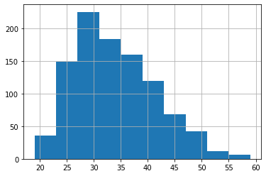

```python
boston.Age.hist();
```

- Most Top Runners are in the late 20's or early 30's
- Outliers go lower on the Right tail

### Parsing Indicators with get_dummies()

get_dummies() method creates Indicator variables out of Categorical variables which are stored as text.

shreds the Categorial variable into separate Indicator columns

```python
boston.head()
```

|  | Name | Age | M/F | City | State | Country | Official Time | Overall | Gender | Years Ran | First Name | Last Name |
| --- | --- | --- | --- | --- | --- | --- | --- | --- | --- | --- | --- | --- |
| 0 | Kirui, Geoffrey | 24 | M | Keringet | NaN | KEN | 2:09:37 | 1 | 1 | NaN | Kirui | Geoffrey |
| 1 | Rupp, Galen | 30 | M | Portland | OR | USA | 2:09:58 | 2 | 2 | NaN | Rupp | Galen |
| 2 | Osako, Suguru | 25 | M | Machida-City | NaN | JPN | 2:10:28 | 3 | 3 | NaN | Osako | Suguru |
| 3 | Biwott, Shadrack | 32 | M | Mammoth Lakes | CA | USA | 2:12:08 | 4 | 4 | NaN | Biwott | Shadrack |
| 4 | Chebet, Wilson | 31 | M | Marakwet | NaN | KEN | 2:12:35 | 5 | 5 | 2015 | Chebet | Wilson |

"Years Ran" : contains information whether the Runner participated in two preceding Marathons

```
- Our Dataset if for 2017, and this column has data whether the runner participated in 2015 and 2016
```

```python
#Checking all NOT NULL values in "Years Ran"
boston[boston['Years Ran'].notnull()]
```

|  | Name | Age | M/F | City | State | Country | Official Time | Overall | Gender | Years Ran | First Name | Last Name |
| --- | --- | --- | --- | --- | --- | --- | --- | --- | --- | --- | --- | --- |
| 4 | Chebet, Wilson | 31 | M | Marakwet | NaN | KEN | 2:12:35 | 5 | 5 | 2015 | Chebet | Wilson |
| 12 | Keflezighi, Meb | 41 | M | San Diego | CA | USA | 2:17:00 | 13 | 13 | 2015 | Keflezighi | Meb |
| 13 | Nyasango, Cutbert | 34 | M | Harara | NaN | ZIM | 2:17:40 | 14 | 14 | 2016 | Nyasango | Cutbert |
| 14 | Korir, Wesley | 34 | M | Kitale | NaN | KEN | 2:18:14 | 15 | 15 | 2015:2016 | Korir | Wesley |
| 29 | Maravilla, Jorge | 39 | M | Mill Valley | CA | USA | 2:24:27 | 30 | 27 | 2016 | Maravilla | Jorge |
| ... | ... | ... | ... | ... | ... | ... | ... | ... | ... | ... | ... | ... |
| 986 | Bretz, Virgil | 44 | M | Mt. Kisco | NY | USA | 2:56:02 | 987 | 931 | 2015:2016 | Bretz | Virgil |
| 987 | Cucuzzella, Mark | 50 | M | Shepherdstown | WV | USA | 2:56:03 | 988 | 932 | 2016 | Cucuzzella | Mark |
| 988 | Carron, John B | 46 | M | Irvington | NY | USA | 2:56:03 | 989 | 933 | 2016 | Carron | John B |
| 995 | Larosa, Mark | 38 | M | North Andover | MA | USA | 2:56:06 | 996 | 940 | 2015:2016 | Larosa | Mark |
| 996 | Williamson, Jerry A | 43 | M | Raleigh | NC | USA | 2:56:06 | 997 | 941 | 2015 | Williamson | Jerry A |

315 rows × 12 columns

This will give us "2015" and "2016" for Years Ran

```python
#Looking at all the Unique values for this field
boston['Years Ran'].unique()
```

```
array([nan, '2015', '2016', '2015:2016'], dtype=object)
```

- we see nan (meaning the runnier did not participate previously)
- we also see a combination of 2015 and 2016 --> 2015:2016

But this is definitely not the best way to store the data

```python
#We got the Indicator variables
boston['Years Ran'].str.get_dummies(sep = ':').head(3)
```

|  | 2015 | 2016 |
| --- | --- | --- |
| 0 | 0 | 0 |
| 1 | 0 | 0 |
| 2 | 0 | 0 |

```python
dummies = boston['Years Ran'].str.get_dummies(sep = ':')
```

```python
boston.columns.get_loc('Years Ran')
```

```
9
```

```python
boston.insert(boston.columns.get_loc('Years Ran'), 'Ran 2015' , dummies['2015'])
boston.insert(boston.columns.get_loc('Years Ran'), 'Ran 2016' , dummies['2016'])
```

```python
boston.head(3)
```

|  | Name | Age | M/F | City | State | Country | Official Time | Overall | Gender | Ran 2015 | Ran 2016 | Years Ran | First Name | Last Name |
| --- | --- | --- | --- | --- | --- | --- | --- | --- | --- | --- | --- | --- | --- | --- |
| 0 | Kirui, Geoffrey | 24 | M | Keringet | NaN | KEN | 2:09:37 | 1 | 1 | 0 | 0 | NaN | Kirui | Geoffrey |
| 1 | Rupp, Galen | 30 | M | Portland | OR | USA | 2:09:58 | 2 | 2 | 0 | 0 | NaN | Rupp | Galen |
| 2 | Osako, Suguru | 25 | M | Machida-City | NaN | JPN | 2:10:28 | 3 | 3 | 0 | 0 | NaN | Osako | Suguru |

#### Q. Which Top Runners from 2017 also ran in the previous two boston marathons

```python
boston[(boston['Ran 2015'] == 1 ) & (boston['Ran 2016'] == 1 )]
```

|  | Name | Age | M/F | City | State | Country | Official Time | Overall | Gender | Ran 2015 | Ran 2016 | Years Ran | First Name | Last Name |
| --- | --- | --- | --- | --- | --- | --- | --- | --- | --- | --- | --- | --- | --- | --- |
| 14 | Korir, Wesley | 34 | M | Kitale | NaN | KEN | 2:18:14 | 15 | 15 | 1 | 1 | 2015:2016 | Korir | Wesley |
| 30 | Ornelas, Zachary | 25 | M | Ann Arbor | MI | USA | 2:24:40 | 31 | 28 | 1 | 1 | 2015:2016 | Ornelas | Zachary |
| 31 | Ayr, Jason M. | 29 | M | Allston | MA | USA | 2:24:49 | 32 | 29 | 1 | 1 | 2015:2016 | Ayr | Jason M. |
| 36 | Vangampleare, Stephen | 26 | M | Colorado Springs | CO | USA | 2:25:35 | 37 | 33 | 1 | 1 | 2015:2016 | Vangampleare | Stephen |
| 56 | Boudalia, Said Sr. | 48 | M | Belluno | NaN | ITA | 2:30:11 | 57 | 51 | 1 | 1 | 2015:2016 | Boudalia | Said Sr. |
| ... | ... | ... | ... | ... | ... | ... | ... | ... | ... | ... | ... | ... | ... | ... |
| 959 | Yu, Michael | 45 | M | Zhubei City, Hsinchu County | NaN | TWN | 2:55:40 | 960 | 907 | 1 | 1 | 2015:2016 | Yu | Michael |
| 962 | Husak, Tyler | 30 | M | Marion | IA | USA | 2:55:42 | 963 | 910 | 1 | 1 | 2015:2016 | Husak | Tyler |
| 977 | Guthals, Nathaniel | 26 | M | Overland Park | KS | USA | 2:55:57 | 978 | 923 | 1 | 1 | 2015:2016 | Guthals | Nathaniel |
| 986 | Bretz, Virgil | 44 | M | Mt. Kisco | NY | USA | 2:56:02 | 987 | 931 | 1 | 1 | 2015:2016 | Bretz | Virgil |
| 995 | Larosa, Mark | 38 | M | North Andover | MA | USA | 2:56:06 | 996 | 940 | 1 | 1 | 2015:2016 | Larosa | Mark |

124 rows × 14 columns

#### How many Top runners from 2017 also ran in 2015?

```python
#Ran 2015 will have 0 for all the players that did not run in 2015
#If we find the sum() of the column "Ran 2015", we end up getting all the runners who participated in 2015 boston Marathon

boston['Ran 2015'].sum()
```

```
190
```

### Text Replacement

- String replacement using exact character Sequences

```python
s = 'welcome to the text manipulation section'
```

```python
s
```

```
'welcome to the text manipulation section'
```

```python
#Appending text to the above string so we have longer string to work with
s += '.This section is about text'
```

```python
s
```

```
'welcome to the text manipulation section.This section is about text'
```

```python
#All instances of "text" have been substituted with 'string'
s.replace('text' , 'string')
```

```
'welcome to the string manipulation section.This section is about string'
```

#### To limit the number of replacements that take place

```python
s.replace('text' , 'string' , 1)
```

```
'welcome to the string manipulation section.This section is about text'
```

```python
boston.sample(10)
```

|  | Name | Age | M/F | City | State | Country | Official Time | Overall | Gender | Ran 2015 | Ran 2016 | Years Ran | First Name | Last Name |
| --- | --- | --- | --- | --- | --- | --- | --- | --- | --- | --- | --- | --- | --- | --- |
| 587 | Moraine, Olivier | 32 | M | Montreal | QC | CAN | 2:50:02 | 588 | 550 | 0 | 0 | NaN | Moraine | Olivier |
| 354 | Atkins, Benjamin | 43 | M | Westlake Village | CA | USA | 2:45:35 | 355 | 328 | 0 | 0 | NaN | Atkins | Benjamin |
| 14 | Korir, Wesley | 34 | M | Kitale | NaN | KEN | 2:18:14 | 15 | 15 | 1 | 1 | 2015:2016 | Korir | Wesley |
| 956 | Kam, Max | 30 | M | San Rafael | CA | USA | 2:55:39 | 957 | 904 | 0 | 1 | 2016 | Kam | Max |
| 154 | Trudel, Samuel | 27 | M | Montreal | QC | CAN | 2:38:37 | 155 | 137 | 0 | 0 | NaN | Trudel | Samuel |
| 274 | Kaehr, Andrew T. | 27 | M | Chicago | IL | USA | 2:43:34 | 275 | 250 | 0 | 1 | 2016 | Kaehr | Andrew T. |
| 80 | Clark, Sean | 31 | M | Glenside | PA | USA | 2:33:03 | 81 | 72 | 0 | 0 | NaN | Clark | Sean |
| 619 | Kellner, John R | 35 | M | Menominee | MI | USA | 2:50:43 | 620 | 580 | 0 | 0 | NaN | Kellner | John R |
| 26 | Humphrey, Luke | 36 | M | Beverly Hills | MI | USA | 2:23:12 | 27 | 24 | 0 | 0 | NaN | Humphrey | Luke |
| 765 | Scott, Reed C. | 22 | M | Lake Huntington | NY | USA | 2:53:01 | 766 | 722 | 0 | 0 | NaN | Scott | Reed C. |

```python
#In the Gender (M/F) column , we want to replace "M" with Male and "F" with female
```

```python
boston['M/F'].str.replace('M' , 'Male').str.replace('F' , 'Female')
```

```
0      Male
1      Male
2      Male
3      Male
4      Male
       ...
995    Male
996    Male
997    Male
998    Male
999    Male
Name: M/F, Length: 1000, dtype: object
```

```python
boston['M/F'].str.replace('M' , 'Male').str.replace('F' , 'Female').value_counts()
```

```
Male      944
Female     56
Name: M/F, dtype: int64
```

```python
boston['M/F'] = boston['M/F'].str.replace('M' , 'Male').str.replace('F' , 'Female')
```

```python
boston.head(3)
```

|  | Name | Age | M/F | City | State | Country | Official Time | Overall | Gender | Ran 2015 | Ran 2016 | Years Ran | First Name | Last Name |
| --- | --- | --- | --- | --- | --- | --- | --- | --- | --- | --- | --- | --- | --- | --- |
| 0 | Kirui, Geoffrey | 24 | Male | Keringet | NaN | KEN | 2:09:37 | 1 | 1 | 0 | 0 | NaN | Kirui | Geoffrey |
| 1 | Rupp, Galen | 30 | Male | Portland | OR | USA | 2:09:58 | 2 | 2 | 0 | 0 | NaN | Rupp | Galen |
| 2 | Osako, Suguru | 25 | Male | Machida-City | NaN | JPN | 2:10:28 | 3 | 3 | 0 | 0 | NaN | Osako | Suguru |

### Case Insensitive Replacement

```python
boston.Country.str.replace('USA' , 'United States')
```

```
0                KEN
1      United States
2                JPN
3      United States
4                KEN
           ...
995    United States
996    United States
997    United States
998    United States
999    United States
Name: Country, Length: 1000, dtype: object
```

```python
#case = False
boston.Country.str.replace('UsA' , 'United States' , case = False)
```

```
0                KEN
1      United States
2                JPN
3      United States
4                KEN
           ...
995    United States
996    United States
997    United States
998    United States
999    United States
Name: Country, Length: 1000, dtype: object
```

### Regular Expressions

For Text Manipulation

#### Regular Expressions help us define highly complex string patterns

https://regex101.com

```python
#We are trying with a test string and targeting the word "phone"
```

It indicates that we got a match which goes from position 3 to position 8:

[figure not shown]

#### Case Sensitive

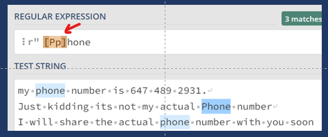

### Working with Meta Characters

#### Matching Digits

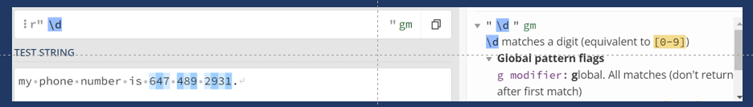

#### Matching white space

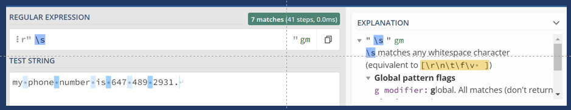

#### Matching word characters

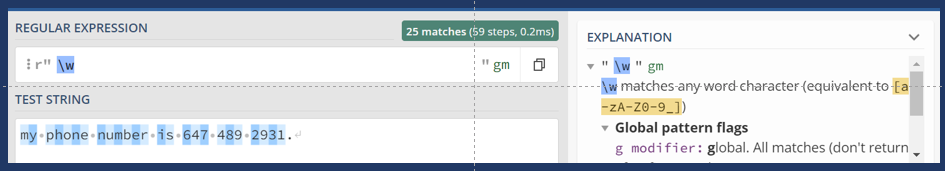

#### Matching dot

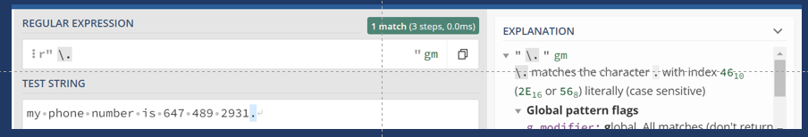

#### combining Meta sequences with Quantifiers to build more advanced Regex patterns

- Meta Sequences : Specify the type of Character we are looking to match
- Quantifiers : Specify how mant characters of that type are we looking for

#### Literally matching "\d"

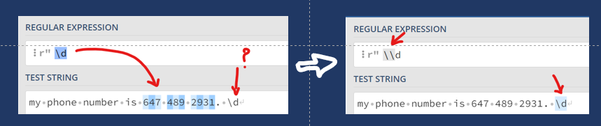

#### Matching Many digits with "+"

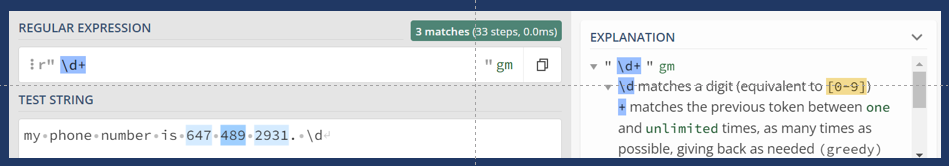

#### This is the pattern where we are matching many digits and a space

```python
#Look at the last set of digits that did not match , since there is no space after the digits
```

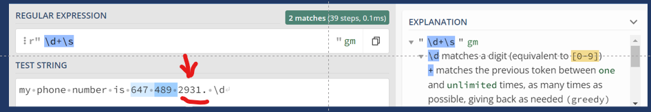

#### To match all three blocks of digits , we need to choose another quantifier

#### "?" : Which indicates 0 or 1 instances of a pattern

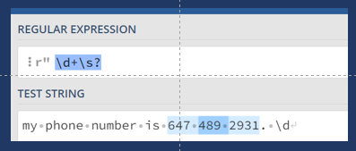

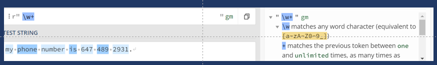

### Matching any character thats not a Digit

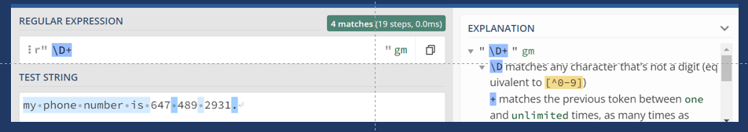

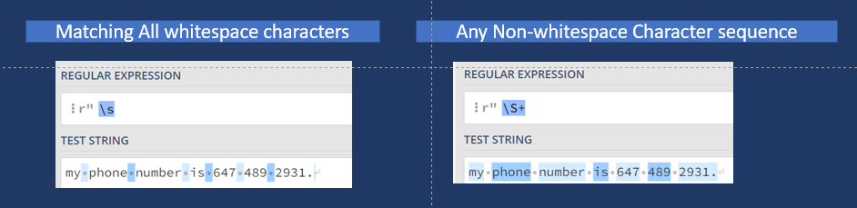

### Character Sets or Character Classes

We can use character sets to indicate a specific character that we want to match

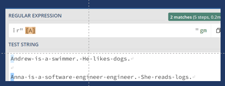

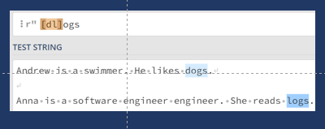

Any character that is not "d" or "l" followed by 'ogs'

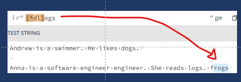

#### What if we want to define a character Set that matched a long list of characters

Rather than specifying each letter individually in the character set like this :

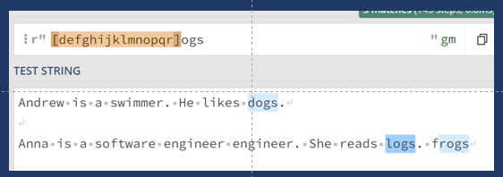

We can simply say : d hyphen r:

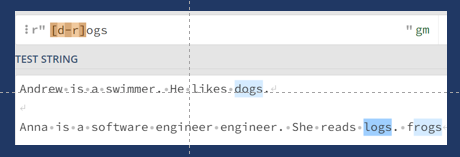

#### If you want all characters :

[a-zA-Z]ogs

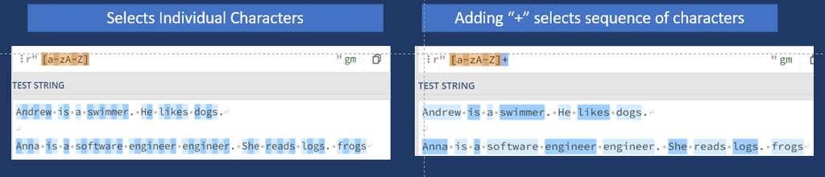

#### Another important concept of Regex is "Capturing Groups"

- Very often instead of matching we need to Extract or Capture information
- We create groups using Parethesis
- Character sets [ ]
- Capturing Groups ( )

Lets assume we want to extract all the proffessions and any word that ends in "er" indicates a Profession or an occupation

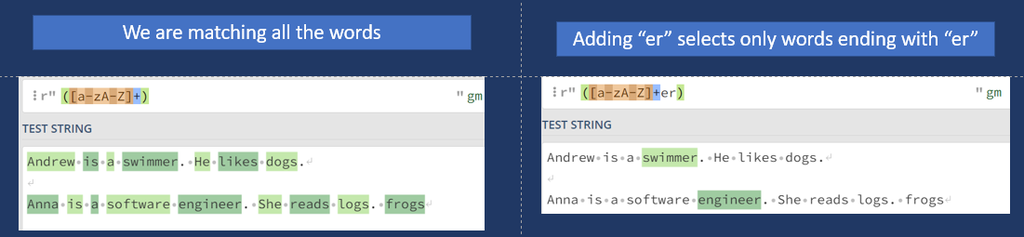

A better way to do this is to use the word character Meta Sequence:

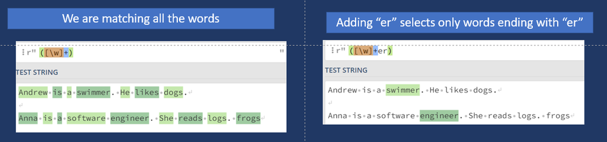

Infact there are many ways to get to the same solution or answer

Match a Sequence of Alphanumeric characters , followed by "er" , followed by space , followed by that same identical pattern we matched initially

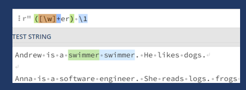

### How to approach Regex ?

We spoke about Quantifiers , how adding a "+" matches one or more character sequences.

There are plenty of Quantifiers in Regex:

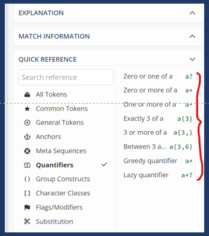

#### Matching groups of 4 digits

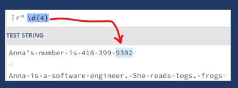

#### We want to match 3 and 4 digit groups : we can spcify an upper bound and a lower bound

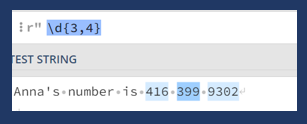

#### Anchors are used to control the word and the Line boundaries in general

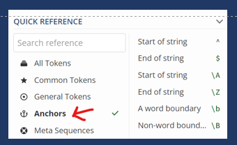

We want to select in this pattern like : "A sentence that begins with "A" and ends in dogs"

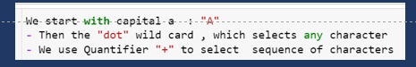

Remember , to capture the literal dot we use "backslash" and then "dot"

"." dot is a wildcard that selects any character

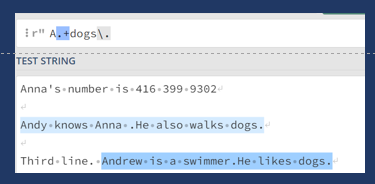

Using Anchors we can make this pattern more tight, we expect this pattern to only match a String from beginning to end.

- If we wanted to select sentences that begin with "A" and end i "dogs."

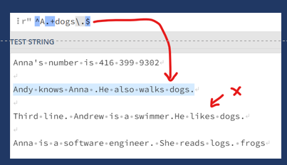

### Validating a List of Passwords that match a required minimal criteria

- minimum 10 characters
- must contain a letter and a number
- andyandy
- andyandy9p
- 1231249dfs931
- 12312902309

.....skip it......

### Practice Regex

#### We are looking at a Real world Problem : "Validation"

- We are looking at Email Validation #### Is this a valid Email?

In Python all Regex functionality is accessed from the "re" module

```python
import re
```

- There are several ways to approach a problem
- But first lets define a pattern , exactly what is it that we are trying to match
- We have two sample email addresses
- hey@andybek.com
- andy@howtopandas.com

word character , followed by any non-whitespace character, we will insert an "@" in it, then a "." to indicate any character after that

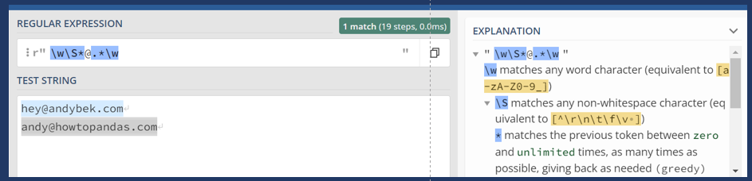

```python
import re
```

```python
#In the below code "r" indicates that its a raw string
```

```python
pattern = r"\w\S*@.*\w"
```

```python
pattern
```

```
'\\w\\S*@.*\\w'
```

```python
re.findall(pattern , 'andy@howtopandas.com')
```

```
['andy@howtopandas.com']
```

If the string is not validated by the pattern , we get an empty result

```python
re.findall(pattern , 'howtopandas.com')
```

```
[]
```

```python
#andy@howtopandas.com ---> "*****@gmail.com"
```

```python
#Create pattern
#- Start with an actually valid email
#- capture the Domain part of the email
#- replace everything except the captured group
```

```python
email = 'andy@howtopandas.com'
```

```python
pattern = r"\w\S*(@.*\w)"
```

```python
#Now we need to replace everything with captured group with "*" Asterisk
#We use another method from the Regular expression module : the "sub" method
#Where we provide the structure of string to be substituted for Group 1
```

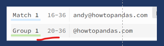

```python
re.sub(pattern , r'***\1' , email)
```

```
'***@howtopandas.com'
```

When deploying such Regex patterns in Realtime environment , check different resources online , the developers might have created much more Robust patterns which could validate Emails better.

### What is the point of re.compile

```python
#There is performance difference between these two things , but the functionality is same
#re.compile is much more Robust
compiled_pattern = re.compile(r"\w\S*(@.*\w)")
raw_pattern = r"\w\S*(@.*\w)"
```

```python
emails = ["andy@andy@andy.com" , "andy@howtopandas.com", "superinvalid|ha.com" , "hey@andybek.com"]
```

```python
#[re.match(raw_pattern , email) for email in emails]
#[re.match(compiled_pattern , email) for email in emails]
```

```python
[re.match(raw_pattern , email) for email in emails]
```

```
[<re.Match object; span=(0, 18), match='andy@andy@andy.com'>,
 <re.Match object; span=(0, 20), match='andy@howtopandas.com'>,
 None,
 <re.Match object; span=(0, 15), match='hey@andybek.com'>]
```

```python
[re.match(compiled_pattern , email) for email in emails]
```

```
[<re.Match object; span=(0, 18), match='andy@andy@andy.com'>,
 <re.Match object; span=(0, 20), match='andy@howtopandas.com'>,
 None,
 <re.Match object; span=(0, 15), match='hey@andybek.com'>]
```

#### Note :

```
This is just an example . Actually it should not validate "andy@andy@andy.com" this email.
```

```python
compiled_pattern = re.compile(r"\w\S*(@.*\w)")
```

```python
string = "andy@pandasbootcamp.com"
```

```python
re.findall(compiled_pattern , string)
```

```
['@pandasbootcamp.com']
```

```python
re.match(compiled_pattern , string)
```

```
<re.Match object; span=(0, 23), match='andy@pandasbootcamp.com'>
```

```python
re.match(compiled_pattern , string).group()
```

```
'andy@pandasbootcamp.com'
```

#### Pandas str contains() ,split() and replace() with Regex

- many of these methods also support Regex

Remember Python does not have a string "contains" method , but Pandas does.

- In the previous lectures we did something like

```python
boston.Name[boston['Name'].str.contains('Will')]
```

```
93            Vanos, William
199        Guzick, William F
415          Hartje, William
429         Adams, William C
456              Cunha, Will
526            Swenson, Will
571    Gates, William E. Jr.
711       Swanson, William G
814        Williamson, David
835             Vargas, Will
892             Rivera, Will
897      Feldman, William P.
936      Decamps, William M.
939        Versen, William R
996      Williamson, Jerry A
Name: Name, dtype: object
```

```python
boston[['Name', 'Age', 'M/F', 'City', 'State', 'Country']][boston['Name'].str.contains('Will')]
```

|  | Name | Age | M/F | City | State | Country |
| --- | --- | --- | --- | --- | --- | --- |
| 93 | Vanos, William | 45 | Male | Orlando | FL | USA |
| 199 | Guzick, William F | 28 | Male | Boston | MA | USA |
| 415 | Hartje, William | 24 | Male | Neptune Beach | FL | USA |
| 429 | Adams, William C | 33 | Male | Arlington | VA | USA |
| 456 | Cunha, Will | 28 | Male | Pittsburgh | PA | USA |
| 526 | Swenson, Will | 45 | Male | Andover | MA | USA |
| 571 | Gates, William E. Jr. | 27 | Male | Maryville | TN | USA |
| 711 | Swanson, William G | 32 | Male | Riverside | CA | USA |
| 814 | Williamson, David | 49 | Male | Sutton | NaN | GBR |
| 835 | Vargas, Will | 42 | Male | Bogota | NaN | COL |
| 892 | Rivera, Will | 46 | Male | Elizabethtown | KY | USA |
| 897 | Feldman, William P. | 31 | Male | Greensboro | NC | USA |
| 936 | Decamps, William M. | 30 | Male | Atlanta | GA | USA |
| 939 | Versen, William R | 25 | Male | Minneapolis | MN | USA |
| 996 | Williamson, Jerry A | 43 | Male | Raleigh | NC | USA |

```python
boston[boston['Name'].str.contains('Will')]
```

|  | Name | Age | M/F | City | State | Country | Official Time | Overall | Gender | Ran 2015 | Ran 2016 | Years Ran | First Name | Last Name |
| --- | --- | --- | --- | --- | --- | --- | --- | --- | --- | --- | --- | --- | --- | --- |
| 93 | Vanos, William | 45 | Male | Orlando | FL | USA | 2:34:40 | 94 | 84 | 0 | 0 | NaN | Vanos | William |
| 199 | Guzick, William F | 28 | Male | Boston | MA | USA | 2:40:43 | 200 | 178 | 0 | 0 | NaN | Guzick | William F |
| 415 | Hartje, William | 24 | Male | Neptune Beach | FL | USA | 2:46:56 | 416 | 386 | 0 | 0 | NaN | Hartje | William |
| 429 | Adams, William C | 33 | Male | Arlington | VA | USA | 2:47:15 | 430 | 399 | 0 | 0 | NaN | Adams | William C |
| 456 | Cunha, Will | 28 | Male | Pittsburgh | PA | USA | 2:47:39 | 457 | 424 | 0 | 0 | NaN | Cunha | Will |
| 526 | Swenson, Will | 45 | Male | Andover | MA | USA | 2:49:10 | 527 | 490 | 1 | 1 | 2015:2016 | Swenson | Will |
| 571 | Gates, William E. Jr. | 27 | Male | Maryville | TN | USA | 2:49:44 | 572 | 534 | 0 | 0 | NaN | Gates | William E. Jr. |
| 711 | Swanson, William G | 32 | Male | Riverside | CA | USA | 2:52:16 | 712 | 670 | 0 | 0 | NaN | Swanson | William G |
| 814 | Williamson, David | 49 | Male | Sutton | NaN | GBR | 2:53:46 | 815 | 768 | 0 | 0 | NaN | Williamson | David |
| 835 | Vargas, Will | 42 | Male | Bogota | NaN | COL | 2:54:07 | 836 | 789 | 0 | 1 | 2016 | Vargas | Will |
| 892 | Rivera, Will | 46 | Male | Elizabethtown | KY | USA | 2:54:53 | 893 | 843 | 0 | 0 | NaN | Rivera | Will |
| 897 | Feldman, William P. | 31 | Male | Greensboro | NC | USA | 2:54:56 | 898 | 848 | 0 | 0 | NaN | Feldman | William P. |
| 936 | Decamps, William M. | 30 | Male | Atlanta | GA | USA | 2:55:22 | 937 | 886 | 0 | 0 | NaN | Decamps | William M. |
| 939 | Versen, William R | 25 | Male | Minneapolis | MN | USA | 2:55:24 | 940 | 889 | 0 | 0 | NaN | Versen | William R |
| 996 | Williamson, Jerry A | 43 | Male | Raleigh | NC | USA | 2:56:06 | 997 | 941 | 1 | 0 | 2015 | Williamson | Jerry A |

### Instead of the string we can use Regex

```python
import re
```

```python
boston.Name[boston.Name.str.contains(r'Will' , regex = True)]
```

```
93            Vanos, William
199        Guzick, William F
415          Hartje, William
429         Adams, William C
456              Cunha, Will
526            Swenson, Will
571    Gates, William E. Jr.
711       Swanson, William G
814        Williamson, David
835             Vargas, Will
892             Rivera, Will
897      Feldman, William P.
936      Decamps, William M.
939        Versen, William R
996      Williamson, Jerry A
Name: Name, dtype: object
```

Good thing is , with REGEX we have more flexibility and Control on our Matching Criteria

```python
#iam at the end
boston.Name[boston.Name.str.contains(r'[Ii][aA][mM]\Z' , regex = True)]
```

```
93      Vanos, William
415    Hartje, William
Name: Name, dtype: object
```

\Z : Means , the position of pattern at end of string

```python
#Include only first names that are exatcly "Wills"
#Isolate first name "Wills"
#Remember Vanos is the last name and William is the First Name in the below example
#Example : Vanos, William
#We spcify the pattern for ", William"  part
```

```python
#But below we are getting "William" as well
boston.Name[boston.Name.str.contains(r',\s[wW]ill' , regex = True)]
```

```
93            Vanos, William
199        Guzick, William F
415          Hartje, William
429         Adams, William C
456              Cunha, Will
526            Swenson, Will
571    Gates, William E. Jr.
711       Swanson, William G
835             Vargas, Will
892             Rivera, Will
897      Feldman, William P.
936      Decamps, William M.
939        Versen, William R
Name: Name, dtype: object
```

```python
#We use the Anchor tag
boston.Name[boston.Name.str.contains(r',\s[wW]ill\Z' , regex = True)]
```

```
456      Cunha, Will
526    Swenson, Will
835     Vargas, Will
892     Rivera, Will
Name: Name, dtype: object
```

```python
boston.iat[456, 0 ] += ' J.'
```

```python
boston.iloc[456]
```

```
Name             Cunha, Will J.
Age                          28
M/F                        Male
City                 Pittsburgh
State                        PA
Country                     USA
Official Time           2:47:39
Overall                     457
Gender                      424
Ran 2015                      0
Ran 2016                      0
Years Ran                   NaN
First Name                Cunha
Last Name                  Will
Name: 456, dtype: object
```

```python
#We have names like these "Cunha, Will J." which also have a Middle name "J." , which is not getting captured above
boston.Name[boston.Name.str.contains(r',\s[wW]ill\b' , regex = True)]
```

[output not shown]

### split()

```python
boston.Name.str.split(expand = True)
```

|  | 0 | 1 | 2 | 3 | 4 |
| --- | --- | --- | --- | --- | --- |
| 0 | Kirui, | Geoffrey | None | None | None |
| 1 | Rupp, | Galen | None | None | None |
| 2 | Osako, | Suguru | None | None | None |
| 3 | Biwott, | Shadrack | None | None | None |
| 4 | Chebet, | Wilson | None | None | None |
| ... | ... | ... | ... | ... | ... |
| 995 | Larosa, | Mark | None | None | None |
| 996 | Williamson, | Jerry | A | None | None |
| 997 | Mccue, | Daniel | T | None | None |
| 998 | Larosa, | John | None | None | None |
| 999 | Sanchez, | Sam | R | None | None |

1000 rows × 5 columns

```python
#With Regex we split on white space
boston.Name.str.split(r'\s' , expand  = True)
```

|  | 0 | 1 | 2 | 3 | 4 |
| --- | --- | --- | --- | --- | --- |
| 0 | Kirui, | Geoffrey | None | None | None |
| 1 | Rupp, | Galen | None | None | None |
| 2 | Osako, | Suguru | None | None | None |
| 3 | Biwott, | Shadrack | None | None | None |
| 4 | Chebet, | Wilson | None | None | None |
| ... | ... | ... | ... | ... | ... |
| 995 | Larosa, | Mark | None | None | None |
| 996 | Williamson, | Jerry | A | None | None |
| 997 | Mccue, | Daniel | T | None | None |
| 998 | Larosa, | John | None | None | None |
| 999 | Sanchez, | Sam | R | None | None |

1000 rows × 5 columns

```python
#we want to change this from "2:09:37" ---> '2 hours 9 minutes, and 37 seconds'
```

- We define three capturing groups to define hours : minutes and Seconds
- Then we define a new replacement string where we reference each of those groups

```python
boston.head(2)
```

|  | Name | Age | M/F | City | State | Country | Official Time | Overall | Gender | Ran 2015 | Ran 2016 | Years Ran | First Name | Last Name |
| --- | --- | --- | --- | --- | --- | --- | --- | --- | --- | --- | --- | --- | --- | --- |
| 0 | Kirui, Geoffrey | 24 | Male | Keringet | NaN | KEN | 2:09:37 | 1 | 1 | 0 | 0 | NaN | Kirui | Geoffrey |
| 1 | Rupp, Galen | 30 | Male | Portland | OR | USA | 2:09:58 | 2 | 2 | 0 | 0 | NaN | Rupp | Galen |

```python
boston['Official Time'].str.replace(r'(\d+):(\d+):(\d+)' , r'\1 hours, \2 minutes , and \3 seconds')
```

```
0      2 hours, 09 minutes , and 37 seconds
1      2 hours, 09 minutes , and 58 seconds
2      2 hours, 10 minutes , and 28 seconds
3      2 hours, 12 minutes , and 08 seconds
4      2 hours, 12 minutes , and 35 seconds
                       ...
995    2 hours, 56 minutes , and 06 seconds
996    2 hours, 56 minutes , and 06 seconds
997    2 hours, 56 minutes , and 06 seconds
998    2 hours, 56 minutes , and 07 seconds
999    2 hours, 56 minutes , and 08 seconds
Name: Official Time, Length: 1000, dtype: object
```